# Statistical Inference Project : Simulation Excercise

Manojkumar Parmar

10/20/2016

## 0.1 Overview

In this report investigation on the **exponential distribution** is performed in R and it is compared with the Central Limit Theorem. As part of report, following aspects are investigated.

- Sample Mean versus Theoretical Mean
- Sample Variance versus Theoretical Variance
- Distribution comparison with normal distribution

## 0.2 Simulations

The exponential distribution can be simulated in R with **rexp(n, lambda)** where lambda ($\lambda$) is the rate parameter. The mean ($\mu$) of exponential distribution is $\frac{1}{\lambda}$ and the standard deviation ($\sigma$) is also $\frac{1}{\lambda}$ (so standard variance ($\sigma^2$) is $\frac{1}{\lambda}^2$). Here for all simulation purpose $\lambda = 0.2$ is used.

### 0.2.1 Simulation methodology:

In investigation report, average of $40$ samples are considered from exponential distributions. Same procedure is reported over $1000$ times to avoid anomalies.

Here is the example of distribution of exponential distribution samples with $\lambda = 0.2$. Additionally, to prove that theoretical mean of distribution $\frac{1}{\lambda}$, simulation is done with law of large numbers.

```r
n = 1000
lambda = 0.2
#generating exp distribution for 1000 samples
base_data = rexp(n,lambda)
# cumulative mean calculation
means <- cumsum(base_data) / (1  : n)
```

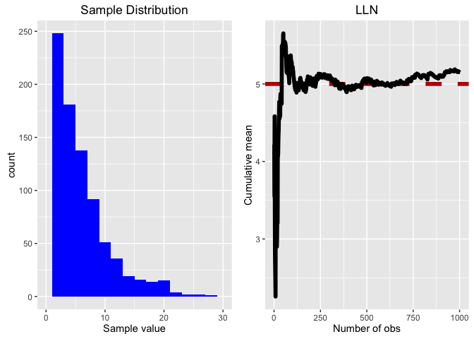

```r
#code for plotting distribution and law of large number
p <- qplot(base_data, geom ='histogram',binwidth = 2,
           main = "Sample Distribution",
      xlab = "Sample value", ylab = "count",
      fill = I("blue"),xlim = c(0,30))
g <- ggplot(data.frame(x = 1 : n, y = means), aes(x = x, y = y))+
        geom_line(size = 1.5)+
        labs(x = "Number of obs", y = "Cumulative mean")+
        geom_hline(yintercept = (1/lambda), colour="#BB0000",
                    linetype="dashed", size = 2)+
        geom_line(size = 2 )+
        ggtitle("LLN")
grid.arrange(p,g, ncol =2)
```

In LLN figure, red dashed line represents the theoretical mean $\frac{1}{\lambda} = \frac{1}{0.2} = 5$. From figure it is clear that exponential distribution mean value approaches theoretical mean as sample size increases.

## 0.3 Analysis of Distribution

For detailed analysis, $40$ samples are derived from exponential distribution having $\lambda = 0.2$. To avoid anomalies in result, $40$ samples are derived $1000$ times and mean of each $40$ sample is stored for further analysis.

```r
nsim = 1000 #repeatation number of experiment

n = 40 #number of samples
lambda= 0.2 #lambda property of exponential distribution

mnsexp = NULL #mean values from every time 40 samples are drawn
varexp = NULL #variance value from every time 40 samples are drawn
thmean = 1/lambda # theoratical mean
thmean
```

```
## [1] 5
```

```r
thsd = 1/lambda #theratical standard deviation for large samples
thssd = thsd/sqrt(n) # theoratical standard deviation for 40 samples
thsd
```

```
## [1] 5
```

```r
thvar = 1/lambda^2 #theoratical variance for large
thsvar = thvar/n #theoratical variance for 40 samples
thvar
```

```
## [1] 25
```

```r
#generate mean and variane distributio
for (i in 1:nsim) {
        samples = rexp(n,lambda)
        mnsexp = c(mnsexp,mean(samples))
        varexp = c(varexp,var(samples))
}
```

- Theoretical mean of exponential distribution is $5$ derived using $\frac{1}{\lambda}$.
- Theoretical standard deviation of exponential distribution is $5$ for large samples and $0.7905694$ with sample size of $40$ derived using $\frac{1/\lambda}{\sqrt[2]{n}}$.
- Theoretical variance of exponential distribution is $25$ for large samples and $0.625$ with sample size of $40$ derived using $\frac{1/\lambda^2}{n}$.

### 0.3.1 Sample Mean versus Theoretical Mean

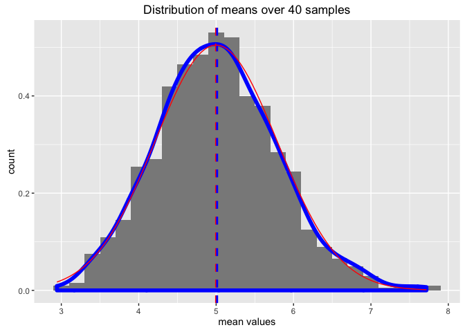

```r
#code for plotting mean distribution
p <- ggplot(data.frame(x = mnsexp),aes(x=x)) +
        geom_histogram(aes(y = ..density..),binwidth = 0.2,fill=I('#8A8A8A')) +
        geom_density(colour = 'blue', size = 2) +
        ggtitle("Distribution of means over 40 samples") +
        labs(x="mean values", y ="count") +
        geom_vline(xintercept = thmean, colour="red",
                   linetype="dashed", size = 1)+
        geom_vline(xintercept = mean(mnsexp), colour="blue",
                   linetype="dashed", size = 1)+
        stat_function(fun = dnorm, args = list(mean = thmean , sd = thssd),
                      colour = "red")

p
```

From above figure it can be concluded that observed mean follows closely the normal distribution.

### 0.3.2 Sample Variance versus Theoretical Variance

Following figure represents distribution of obtained variances over $1000$ trials of $40$ samples of exponential distribution. Dashed blue lines represents the obtained mean of variances from samples and dashed red line represents the theoretical variance.

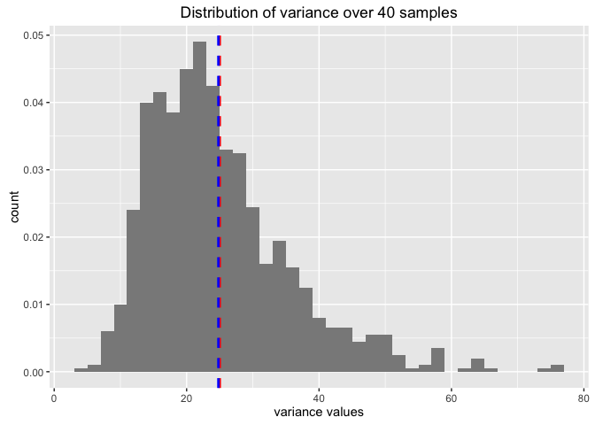

```r
#code for plotting variance distribution
q <- ggplot(data.frame(x = varexp),aes(x)) +
        geom_histogram(aes(y = ..density..),binwidth = 2,fill=I('#8A8A8A')) +
        ggtitle("Distribution of variance over 40 samples") +
        labs(x="variance values", y ="count") +
        geom_vline(xintercept = thvar, colour="red",
                   linetype="dashed", size = 1)+
        geom_vline(xintercept = mean(varexp), colour="blue",
                   linetype="dashed", size = 1)
q
```

### 0.3.3 Distribution comparision with normal distribution

However, mathematical properties with respect to standard deviations can be used to prove that distribution is normal. Note that for standard normal distribution, approximately $68\%$, $95\%$ and $99\%$ of the normal density lies within $1$, $2$ and $3$ standard deviations from the mean, respectively.

Following R function samplecoverage is written to analyse the property of standard normal with respect to coverage of samples corresponding to standard deviation.

```r
# function to calculate sample coverage for given standard distribution
samplecoverage <- function(sample, nsd){
        #sample - sample of data
        #nsd - no. of standard deviation (always >= 0)
        smean = mean(sample) #mean of samples
        ssd =sd(sample) # sd of samples
        ul = smean + nsd * ssd # calculate lower limit for given sd
        ll = smean - nsd * ssd # calculate uper limit for given sd
        coverage = sample > ll & sample < ul # calculate samples falling in limits
        round((sum(coverage) / length(sample))*100,2) # return percentage coverage
}
```

By using above function, following code finds coverage for $1^{st}$, $2^{nd}$ and $3^{rd}$ standard deviation.

```r
# code to generate sample coverage for 1,2 and 3 standardd deviations
for (i in  1:3){
       print(paste0("Coverage for ",i," standard deviation = ",
                    samplecoverage(mnsexp,i), "%"))
}
```

```
## [1] "Coverage for 1 standard deviation = 69.6%"
## [1] "Coverage for 2 standard deviation = 95%"
## [1] "Coverage for 3 standard deviation = 99.6%"
```

From analysis of sample coverage, it is clear that generated distribution follows the normal distribution.

#### 0.3.3.3 Mathematical : Using quantiles

Additionally, quantiles comparison with normal distribution is carried out using following code.

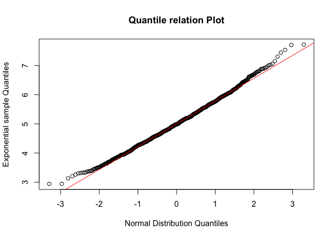

```r
qqnorm(mnsexp,main ="Quantile relation Plot",
       xlab = "Normal Distribution Quantiles",
       ylab = "Exponential sample Quantiles")
qqline(mnsexp,col = "2")
```

From analysis of the figure it is evident that distribution is following normal distribution quntiles linearly.